# Diversité

19 juin 2023

## Motivation

## La question

Comment mesurer la diversité et la structuration spatiale ?

Applications :

- mesure de la biodiversité ;
- mesure de la concentration spatiale et de la spécialisation en économie géographique.

## Les outils

L’entropie mesure :

- le désordre (physique statistique, 19<sup>ème</sup> siècle) ;
- l’incertitude (théorie de l’information, Shannon 1948) ;
- l’inégalité (Theil 1967).

## La présentation

Les méthodes utilisées :

- L’entropie classique ;
- Sa généralisation ;
- Les nombres effectifs.

Transfert des développement de la littérature sur la biodiversité à l’économie géographique.

## Les données

Eurostat : Effectifs salariés de 19 secteurs industriels dans 25 pays européens.

BCI : Nombre d’arbres de 50 parcelles d’un hectare de la forêt de Barro Colorado Island (Panama), appartenant à 225 espèces. 25000 arbres mesurés : inventaire exceptionnel.

Paracou : Inventaires de deux hectares de forêts tropicale en Guyane française (Parcelles 6 et 18). 600 arbres environ par hectare : inventaire très insuffisant.

## L’entropie

## Définir le désordre

A l’origine, Carnot (1824)

- Second principe de la thermodynamique.

Précisément :

- Transfert de chaleur, \(\mathrm{d}Q\), à somme nulle (1<sup>er</sup> principe) ;
- Tiédissement : \(\mathrm{d}Q/T\), à somme positive (2<sup>nd</sup> principe). Augmentation du désordre.

Remarque : l’entropie est définie par sa variation (étymologie: *transformation*).

## Boltzmann

Un gaz est un ensemble de particules, chacune ayant plusieurs états possibles.

L’entropie est proportionnelle au logarithme du nombre d’états possibles de l’ensemble des particules (1877, traduit par Sharp and Matschinsky 2015).

Lien avec le second principe.

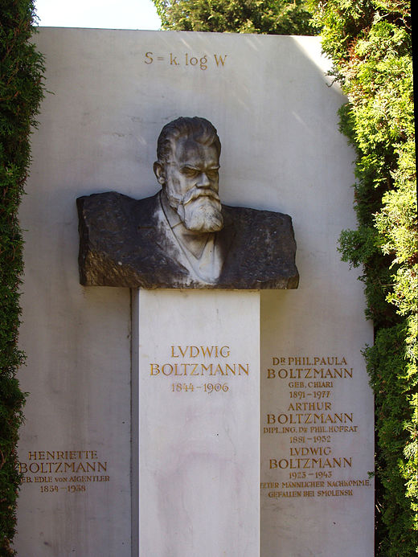

Tombe de Boltzmann

## Mesurer le désordre

Définition d’une chaîne de caractères :

- longueur \(n\) ;
- alphabet probabilisé.

Exemple :

- 3 lettres, {a, b, c}, fréquences (1/2, 1/3, 1/6) ;
- Combien de chaînes de 60 caractères ?
- Le logarithme du nombre de chaînes est \(n\) fois l’entropie : \(61\).

L’entropie de Shannon mesure la complexité de la distribution de {a, b, c}, indépendamment de la longueur de la chaîne : 1.01

## Mesurer l’incertitude

Expérience à plusieurs résultats possibles.

- La probabilité d’obtenir \(r_s\) est \(p_s\).

Fonction d’information : \(I(p_s)\), entre \(I(0)=+\infty\) et \(I(1)=0\).

- Définition : la rareté est \(1/p_s\).
- Le logarithme de la rareté est la fonction d’information de Shannon.

L’information moyenne apportée par un individu est l’entropie de Shannon: \[\sum_s{p_s \ln {\frac{1}{p_s}}}\]

## Entropie généralisée

Autres entropies : Rényi, Shorrocks… Tsallis (1988)

Paramétriques.

Logarithme déformé : \(\ln_q{x} = \frac{x^{1-q}-1}{1-q}\).

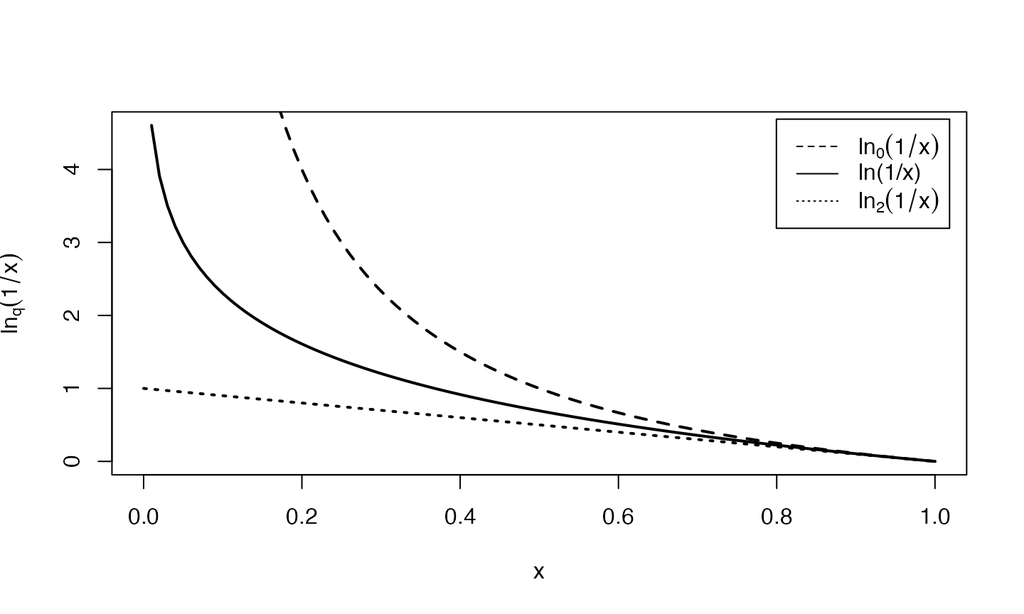

## Formalisation

L’entropie de Tsallis est la moyenne du logarithme (déformé, d’ordre \(q\)) de la rareté.

L’ordre \(q\) donne une importance plus ou moins grande aux petites probabilités.

- Entropie d’ordre 0 : le nombre de catégories (-1) ;
- Entropie d’ordre 1 : Shannon ;
- Entropie d’ordre 2 : Simpson (1-Herfindahl).

## Nombres de Hill

Nombre de catégories équiprobables de même entropie que celle du système observé (Hill 1973).

Mesure interprétable et comparable quelque soit l’ordre de diversité.

Exponentielle (déformée: \(e^x_q = \left[ 1+\left( 1-q \right)x \right]^{\frac{1}{1-q}}\)) de l’entropie (Marcon et al. 2014).

## Profil de diversité

Comparaison de la diversité des deux parcelles de la forêt de Paracou.

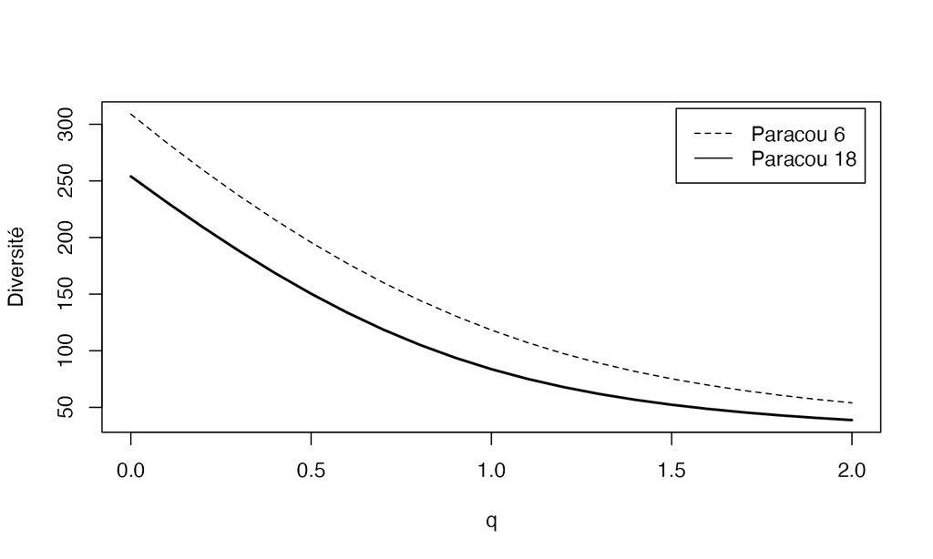

## TP

## Pratiquer

Calcul de la diversité avec R : fichier `TP1.Rmd`.

## Questions similaires entre disciplines

Biodiversité :

- Nombres d’arbres par espèces dans un habitat forestier : biodiversité.

Economie :

- Nombre d’employés par secteur industriel dans un pays : diversité = contraire de la spécialisation.

Traduction possible.

## Spécialisation absolue

Transformation simple :

(Nb Secteurs - Diversité) / (Nb Secteurs - 1)

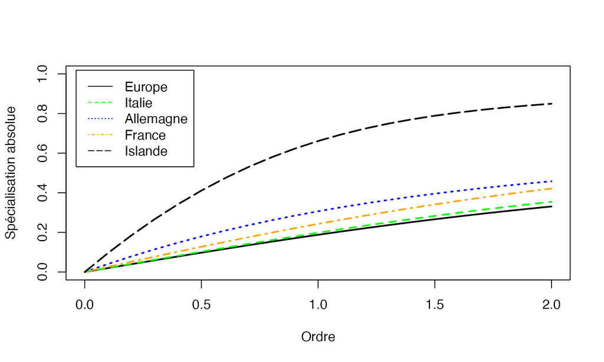

## Décomposition de l’entropie

## Entropie relative

Ecart d’une distribution observée à une distribution attendue.

- Divergence de Kullback-Leibler ;
- Entropie relative de Theil.

Généralisation à l’ordre \(q\) (Marcon et al. 2014).

La distribution attendue est la moyenne des distributions, donc l’entropie relative mesure à quel point chaque distribution est différente de la moyenne.

## Exemple

Décomposition de l’entropie non limitée à l’ordre 1.

## Décomposition de la biodiversité

Whittaker (1960) définit les diversités :

- \(\alpha\) : moyenne des diversités locales
- \(\gamma\) : diversité globale
- \(\beta\) : l’écart entre les deux.

L’entropie \(\gamma\) est la somme des entropies \(\alpha\) et \(\beta\).

La diversité est l’exponentielle de l’entropie donc la diversité \(\gamma\) est le produit des diversités \(\alpha\) et \(\beta\).

Résultat immédiat pour \(q=1\), étendu à \(q\) quelconque (Jost 2006; Marcon et al. 2014).

## Nombres de Hill

A BCI, la diversité \(\alpha\) d’ordre 1 est \(46\) espèces par parcelle d’un hectare.

La diversité \(\gamma\) est \(72\) espèces effectives.

La diversité \(\beta\) est le rapport des deux, c’est-à-dire \(1.6\) parcelles effectives.

Parcelles effectives : parcelles de même poids, ne comprenant aucune espèce commune.

## Nombres de Hill

La même décomposition montre que les deux parcelles de Paracou sont aussi différentes que les 50 de BCI :

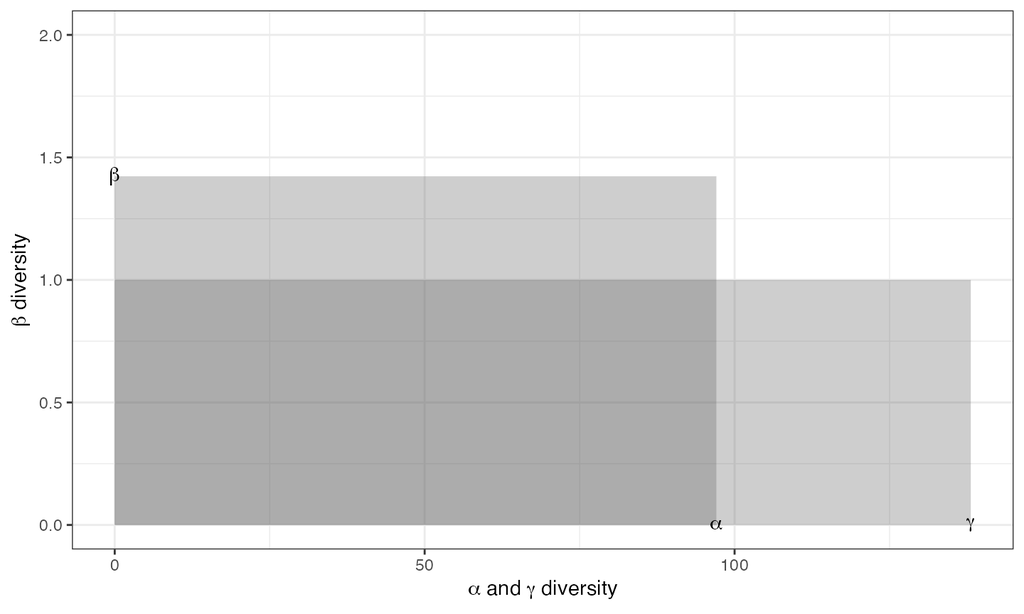

## Profils de diversité

Diversité des secteurs industriels en Europe :

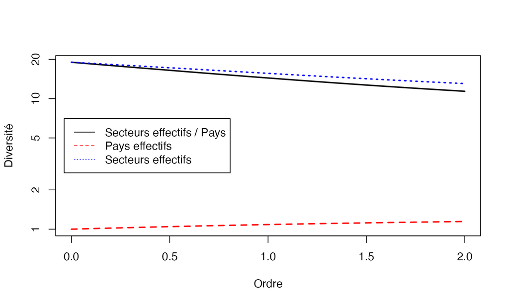

## TP

## Pratiquer

Décomposition de la diversité : fichier `TP2.Rmd`.

## Conclusion

## Concepts identiques, expression contraire

Diversité \(\leftrightarrow\) Spécialisation.

Raison : mise en avant de l’aspect positif.

## Absolu et relatif

Diversités \(\alpha\) et \(\gamma\) absolues, \(\beta\) relative.

Approches complémentaires dans la littérature économique.

Unification par l’entropie :

- liens étroits : significativité de l’une \(\iff\) significativité de l’autre ;
- information très différente.

## Interfertilisation

De la physique à l’écologie : entropie de Tsallis.

De la théorie de l’information à l’écologie : divergence de Kullback and Leibler (1951).

De la théorie de l’information à l’économie : entropie relative de Theil.

En écologie : nombres effectifs.

## References

Hill, M. O. 1973. “ Diversity and Evenness: A Unifying Notation and Its Consequences.” *Ecology* 54 (2): 427–32. https://doi.org/10.2307/1934352.

Jost, Lou. 2006. “ Entropy and diversity.” *Oikos* 113 (2): 363–75. https://doi.org/10.1111/j.2006.0030-1299.14714.x.

Kullback, S., and R. A. Leibler. 1951. “ On Information and Sufficiency.” *The Annals of Mathematical Statistics* 22 (1): 79–86.

Marcon, Eric, Ivan Scotti, Bruno Hérault, Vivien Rossi, and Gabriel Lang. 2014. “ Generalization of the Partitioning of Shannon Diversity.” *Plos One* 9 (3): e90289. https://doi.org/10.1371/journal.pone.0090289.

Shannon, Claude E. 1948. “ A Mathematical Theory of Communication.” *The Bell System Technical Journal* 27: 379–423, 623–56.

Sharp, Kim, and Franz Matschinsky. 2015. “ Translation of Ludwig Boltzmann’s paper "on the relationship between the second fundamental theorem of the mechanical theory of heat and probability calculations regarding the conditions for thermal equilibrium".” *Entropy* 17 (4): 1971–2009. https://doi.org/10.3390/e17041971.

Theil, H. 1967. *Economics and Information Theory*. Chicago: Rand McNally & Company.

Tsallis, Constantino. 1988. “ Possible generalization of Boltzmann-Gibbs statistics.” *Journal of Statistical Physics* 52 (1): 479–87. https://doi.org/10.1007/BF01016429.

Whittaker, R. H. 1960. “ Vegetation of the Siskiyou Mountains, Oregon and California.” *Ecological Monographs* 30 (3): 279–338. https://doi.org/10.2307/1943563.